# AI CW2: Universal Workflow on IMDB Spoilers Dataset

# Model 1: Dense Model

The following code cells contain my initial model for this problem. Here I am seeking to prove that statistical power is achievable by producing a simple bag-of-words model. The model definition can be seen below.

```python
model = build_small()
```

```
Model: "sequential_1"
_________________________________________________________________
 Layer (type)                Output Shape              Param #
=================================================================
 embedding_1 (Embedding)     (None, 500, 8)            120000

 flatten_1 (Flatten)         (None, 4000)              0

 dense_2 (Dense)             (None, 32)                128032

 dense_3 (Dense)             (None, 1)                 33

=================================================================
Total params: 248,065
Trainable params: 248,065
Non-trainable params: 0
_________________________________________________________________
```

```python
history = train(model, 50)
```

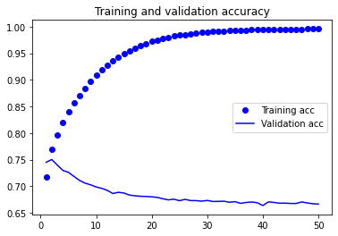

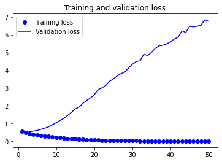

```python
plot_outputs()
```

# Model 2: First LSTM Model

```python
model = build_scaled_up()
```

```
Model: "sequential"
_________________________________________________________________
 Layer (type)                Output Shape              Param #
=================================================================
 embedding (Embedding)       (None, None, 8)           120000

 lstm (LSTM)                 (None, 32)                5248

 dense (Dense)               (None, 1)                 33

=================================================================
Total params: 125,281
Trainable params: 125,281
Non-trainable params: 0
_________________________________________________________________
```

```python
history = train(model, 50)
```

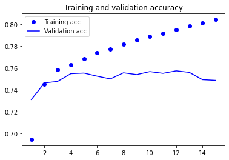

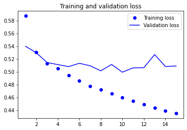

```python
plot_outputs()
```

# Tuning: Dropout

## Model 3: Rate 20%

```python
model = build_dropout(0.2, 0.2)
```

```
Model: "sequential_1"
_________________________________________________________________
 Layer (type)                Output Shape              Param #
=================================================================
 embedding_1 (Embedding)     (None, None, 8)           120000

 lstm_1 (LSTM)               (None, 32)                5248

 dense_1 (Dense)             (None, 1)                 33

=================================================================
Total params: 125,281
Trainable params: 125,281
Non-trainable params: 0
_________________________________________________________________
```

```python
history = train(model, 50)
```

Below I have included graphs showing the training and validation accuracy and loss of this model:

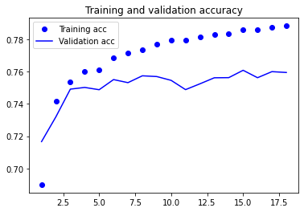

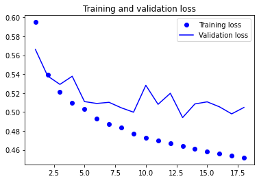

```python
plot_outputs()
```

## Model 4: Rate 40%

```python
model = build_dropout(0.4, 0.4)
```

```
Model: "sequential"
_________________________________________________________________
 Layer (type)                Output Shape              Param #
=================================================================
 embedding (Embedding)       (None, None, 8)           120000

 lstm (LSTM)                 (None, 32)                5248

 dense (Dense)               (None, 1)                 33

=================================================================
Total params: 125,281
Trainable params: 125,281
Non-trainable params: 0
_________________________________________________________________
```

```python
history = train(model, 50)
```

Graphs showing the training and validation loss and accuracy can be found below:

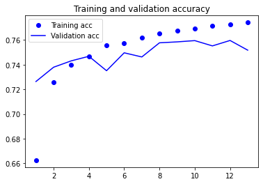

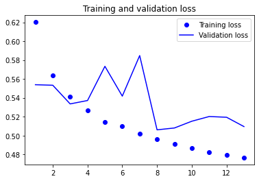

```python
plot_outputs()
```

## Model 5: Rate 30%

```python
model = build_dropout(0.3, 0.3)
```

```
Model: "sequential"
_________________________________________________________________
 Layer (type)                Output Shape              Param #
=================================================================
 embedding (Embedding)       (None, None, 8)           120000

 lstm (LSTM)                 (None, 32)                5248

 dense (Dense)               (None, 1)                 33

=================================================================
Total params: 125,281
Trainable params: 125,281
Non-trainable params: 0
_________________________________________________________________
```

```python
history = train(model, 50)
```

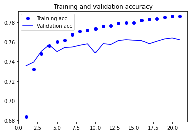

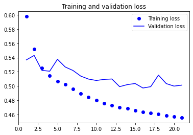

```python
plot_outputs()
```

# Tuning: Number of Layers

Next, I will be changing the architecture by adding layers. Adding layers will increase the capacity of the network, making it more likely to learn important patterns that can allow it to make more accurate predictions.

## Model 6: 2 Layers

For the next model, I will be increasing the number of LSTM layers to 2. The model definition can be seen below.

```python
model = build_layers(0.4, 0.4, 2)
```

```
Model: "sequential"
_________________________________________________________________
 Layer (type)                Output Shape              Param #
=================================================================
 embedding (Embedding)       (None, None, 8)           120000

 lstm (LSTM)                 (None, None, 32)          5248

 lstm_1 (LSTM)               (None, 32)                8320

 dense (Dense)               (None, 1)                 33

=================================================================
Total params: 133,601
Trainable params: 133,601
Non-trainable params: 0
_________________________________________________________________
```

```python
history = train(model, 50)
```

# Model 7: First GRU Model

```python
model = build_GRU(0.2, 0.2)
```

```
Model: "sequential_5"
_________________________________________________________________
 Layer (type)                Output Shape              Param #
=================================================================
 embedding_5 (Embedding)     (None, None, 8)           120000

 gru_8 (GRU)                 (None, 32)                4032

 dense_5 (Dense)             (None, 1)                 33

=================================================================
Total params: 124,065
Trainable params: 124,065
Non-trainable params: 0
_________________________________________________________________
```

```python
history = train(model, 50)
```

```python
plot_outputs()
```

[output not shown]

# Tuning: Learning Rate

## Model 8: 0.003

```python
model = build_learning_rate(0.2, 0.2, 0.003)
```

```
Model: "sequential_5"
_________________________________________________________________
 Layer (type)                Output Shape              Param #
=================================================================
 embedding_5 (Embedding)     (None, None, 8)           120000

 gru_5 (GRU)                 (None, 32)                4032

 dense_5 (Dense)             (None, 1)                 33

=================================================================
Total params: 124,065
Trainable params: 124,065
Non-trainable params: 0
_________________________________________________________________
```

```python
history = train(model, 50)
```

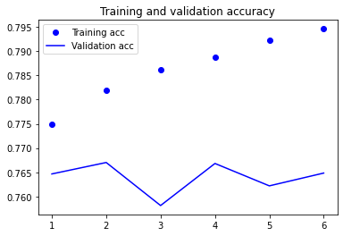

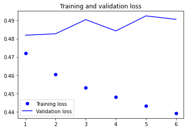

```python
plot_outputs()
```

## Model 9: 0.006

```python
model = build_learning_rate(0.2, 0.2, 0.006)
```

```python
history = train(model, 50)
```

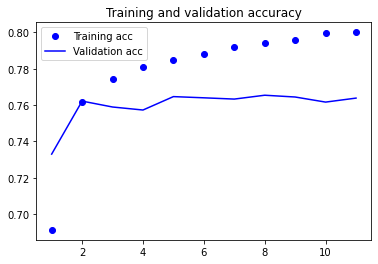

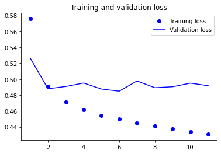

```python
plot_outputs()
```

## Model 10: 0.004

```python
model = build_learning_rate(0.4, 0.4, 0.004)
```

```
Model: "sequential_2"
_________________________________________________________________
 Layer (type)                Output Shape              Param #
=================================================================
 embedding_2 (Embedding)     (None, None, 8)           120000

 gru_2 (GRU)                 (None, 32)                4032

 dense_2 (Dense)             (None, 1)                 33

=================================================================
Total params: 124,065
Trainable params: 124,065
Non-trainable params: 0
_________________________________________________________________
```

```python
history = train(model, 50)
```

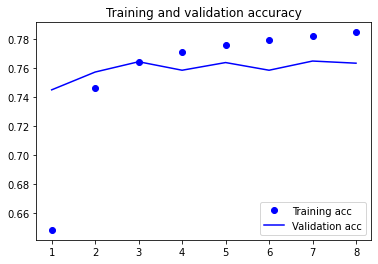

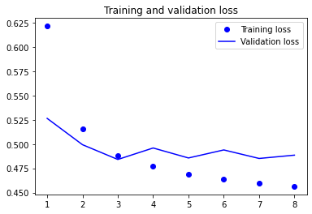

```python
plot_outputs()
```

```python
model = build_learning_rate(0.4, 0.4, 0.01)
```

```
Model: "sequential_4"
_________________________________________________________________
 Layer (type)                Output Shape              Param #
=================================================================
 embedding_4 (Embedding)     (None, None, 8)           120000

 gru_4 (GRU)                 (None, 32)                4032

 dense_4 (Dense)             (None, 1)                 33

=================================================================
Total params: 124,065
Trainable params: 124,065
Non-trainable params: 0
_________________________________________________________________
```

```python
history = train(model, 50)
```

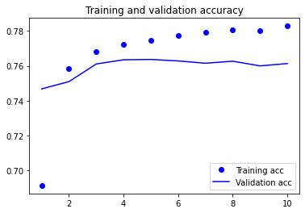

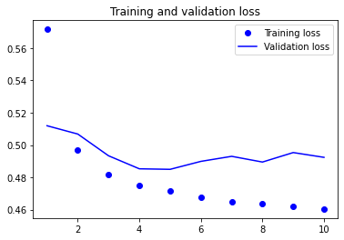

```python
plot_outputs()
```

# Training Final Model

```python
model = build_learning_rate(0.2, 0.2, 0.003)
```

```
Model: "sequential"
_________________________________________________________________
 Layer (type)                Output Shape              Param #
=================================================================
 embedding (Embedding)       (None, None, 8)           120000

 gru (GRU)                   (None, 32)                4032

 dense (Dense)               (None, 1)                 33

=================================================================
Total params: 124,065
Trainable params: 124,065
Non-trainable params: 0
_________________________________________________________________
```

```python
history = train_final_model(model, 1)
```

```python
results = evaluate()
```

[output not shown]